# 10 Years of Historical Price 01/09/2008 ~ 01/09/2018

SECTION 0 - OBTAIN AND TRANSFORMING DATA

3M CSV dataset

```r
dataset_MMM <- read.csv("MMM.csv")
head(dataset_MMM)
```

|  | Date | Open | High | Low | Close | Adj.Close | Volume |
| --- | --- | --- | --- | --- | --- | --- | --- |
| 1 | 2008-01-08 | 81.35 | 82.07 | 80.10 | 80.21 | 60.62685 | 5711200 |
| 2 | 2008-01-09 | 80.20 | 80.82 | 78.49 | 80.19 | 60.61175 | 6422300 |
| 3 | 2008-01-10 | 79.75 | 80.71 | 79.02 | 80.21 | 60.62685 | 6835800 |
| 4 | 2008-01-11 | 79.63 | 81.06 | 76.97 | 77.58 | 58.63898 | 8414500 |
| 5 | 2008-01-14 | 78.13 | 78.64 | 77.50 | 78.50 | 59.33435 | 2927600 |
| 6 | 2008-01-15 | 78.00 | 78.70 | 77.03 | 77.18 | 58.33664 | 4206500 |

```r
summary(dataset_MMM)
```

```
         Date           Open             High             Low
 2008-01-08:   1   Min.   : 41.31   Min.   : 42.45   Min.   : 40.87
 2008-01-09:   1   1st Qu.: 81.26   1st Qu.: 81.83   1st Qu.: 80.50
 2008-01-10:   1   Median : 96.92   Median : 97.50   Median : 96.57
 2008-01-11:   1   Mean   :118.35   Mean   :119.20   Mean   :117.52
 2008-01-14:   1   3rd Qu.:157.59   3rd Qu.:158.46   3rd Qu.:156.73
 2008-01-15:   1   Max.   :243.19   Max.   :244.23   Max.   :239.18
 (Other)   :2513
     Close          Adj.Close          Volume
 Min.   : 41.83   Min.   : 32.86   Min.   :  651000
 1st Qu.: 81.22   1st Qu.: 66.41   1st Qu.: 2026100
 Median : 97.21   Median : 82.92   Median : 2782500
 Mean   :118.42   Mean   :105.61   Mean   : 3288103
 3rd Qu.:157.65   3rd Qu.:145.32   3rd Qu.: 3943750
 Max.   :243.14   Max.   :238.47   Max.   :16317000
```

C CSV dataset

```r
dataset_C <- read.csv("C.csv")
head(dataset_C)
```

|  | Date | Open | High | Low | Close | Adj.Close | Volume |
| --- | --- | --- | --- | --- | --- | --- | --- |
| 1 | 2008-09-02 | 196.3 | 198.2 | 188.8 | 191.1 | 182.3512 | 7979000 |
| 2 | 2008-09-03 | 191.2 | 196.6 | 187.7 | 196.1 | 187.1223 | 6362700 |
| 3 | 2008-09-04 | 193.0 | 194.7 | 182.1 | 183.0 | 174.6220 | 8057300 |
| 4 | 2008-09-05 | 180.5 | 191.8 | 179.3 | 190.7 | 181.9695 | 8401400 |
| 5 | 2008-09-08 | 208.4 | 209.5 | 195.0 | 203.2 | 193.8972 | 17043000 |
| 6 | 2008-09-09 | 200.2 | 203.8 | 188.1 | 188.8 | 180.1565 | 11634800 |

```r
summary(dataset_C)
```

```
         Date           Open             High             Low
 2008-09-02:   1   Min.   : 10.20   Min.   : 10.70   Min.   :  9.70
 2008-09-03:   1   1st Qu.: 39.34   1st Qu.: 39.90   1st Qu.: 38.59
 2008-09-04:   1   Median : 47.60   Median : 48.00   Median : 47.07
 2008-09-05:   1   Mean   : 50.17   Mean   : 50.91   Mean   : 49.28
 2008-09-08:   1   3rd Qu.: 54.46   3rd Qu.: 54.95   3rd Qu.: 54.01
 2008-09-09:   1   Max.   :231.60   Max.   :235.00   Max.   :220.00
 (Other)   :2513
     Close          Adj.Close           Volume
 Min.   : 10.20   Min.   :  9.747   Min.   :  3998000
 1st Qu.: 39.10   1st Qu.: 37.393   1st Qu.: 16221050
 Median : 47.56   Median : 45.603   Median : 24164500
 Mean   : 50.04   Mean   : 48.246   Mean   : 32159178
 3rd Qu.: 54.48   3rd Qu.: 52.304   3rd Qu.: 39243400
 Max.   :230.00   Max.   :219.470   Max.   :377263800
```

PG CSV dataset

```r
dataset_PG <- read.csv("PG.csv")
head(dataset_PG)
```

|  | Date | Open | High | Low | Close | Adj.Close | Volume |
| --- | --- | --- | --- | --- | --- | --- | --- |
| 1 | 2008-09-02 | 70.35 | 71.43 | 70.15 | 70.47 | 51.39056 | 11255200 |
| 2 | 2008-09-03 | 70.42 | 71.50 | 70.18 | 71.42 | 52.08335 | 10433900 |
| 3 | 2008-09-04 | 71.16 | 71.52 | 70.37 | 70.44 | 51.36869 | 12298000 |
| 4 | 2008-09-05 | 70.39 | 71.07 | 69.73 | 70.78 | 51.61662 | 11578800 |
| 5 | 2008-09-08 | 71.33 | 72.48 | 71.31 | 72.37 | 52.77613 | 16521200 |
| 6 | 2008-09-09 | 71.66 | 72.46 | 71.47 | 71.89 | 52.42612 | 18542200 |

```r
summary(dataset_PG)
```

```
         Date           Open            High            Low
 2008-09-02:   1   Min.   :44.51   Min.   :45.19   Min.   :39.37
 2008-09-03:   1   1st Qu.:63.40   1st Qu.:63.80   1st Qu.:62.97
 2008-09-04:   1   Median :76.39   Median :76.99   Median :75.81
 2008-09-05:   1   Mean   :73.44   Mean   :73.93   Mean   :72.96
 2008-09-08:   1   3rd Qu.:82.56   3rd Qu.:83.08   3rd Qu.:82.10
 2008-09-09:   1   Max.   :94.17   Max.   :94.67   Max.   :93.83
 (Other)   :2513
     Close         Adj.Close         Volume
 Min.   :44.18   Min.   :32.65   Min.   :  2196700
 1st Qu.:63.33   1st Qu.:49.97   1st Qu.:  7058250
 Median :76.41   Median :66.62   Median :  8970100
 Mean   :73.46   Mean   :63.62   Mean   : 10524215
 3rd Qu.:82.62   3rd Qu.:76.19   3rd Qu.: 11791750
 Max.   :94.40   Max.   :91.31   Max.   :123735700
```

GOOG CSV dataset

```r
dataset_GOOG <- read.csv("GOOG.csv")
head(dataset_GOOG)
```

|  | Date | Open | High | Low | Close | Adj.Close | Volume |
| --- | --- | --- | --- | --- | --- | --- | --- |
| 1 | 2008-09-02 | 236.8446 | 239.5321 | 229.2191 | 231.1218 | 231.1218 | 12302400 |
| 2 | 2008-09-03 | 232.8505 | 235.6126 | 228.3051 | 230.7045 | 230.7045 | 8685300 |
| 3 | 2008-09-04 | 228.5137 | 230.1233 | 223.2480 | 223.6752 | 223.6752 | 9759900 |
| 4 | 2008-09-05 | 221.3056 | 224.7681 | 218.6181 | 220.6896 | 220.6896 | 9127500 |
| 5 | 2008-09-08 | 224.5495 | 225.0065 | 207.4259 | 208.6181 | 208.6181 | 18153000 |
| 6 | 2008-09-09 | 210.2177 | 214.7930 | 206.1591 | 207.9773 | 207.9773 | 14553100 |

```r
summary(dataset_GOOG)
```

```
         Date           Open             High             Low
 2008-09-02:   1   Min.   : 130.4   Min.   : 133.8   Min.   : 122.9
 2008-09-03:   1   1st Qu.: 285.6   1st Qu.: 287.6   1st Qu.: 282.7
 2008-09-04:   1   Median : 444.0   Median : 446.0   Median : 440.2
 2008-09-05:   1   Mean   : 515.8   Mean   : 520.1   Mean   : 511.2
 2008-09-08:   1   3rd Qu.: 722.8   3rd Qu.: 727.3   3rd Qu.: 716.5
 2008-09-09:   1   Max.   :1271.0   Max.   :1273.9   Max.   :1249.0
 (Other)   :2513
     Close          Adj.Close          Volume
 Min.   : 127.9   Min.   : 127.9   Min.   :    7900
 1st Qu.: 286.0   1st Qu.: 286.0   1st Qu.: 1657600
 Median : 442.6   Median : 442.6   Median : 3445800
 Mean   : 515.8   Mean   : 515.8   Mean   : 4289452
 3rd Qu.: 720.8   3rd Qu.: 720.8   3rd Qu.: 5423650
 Max.   :1268.3   Max.   :1268.3   Max.   :32690500
```

MYL CSV dataset

```r
dataset_MYL <- read.csv("MYL.csv")
head(dataset_MYL)
```

|  | Date | Open | High | Low | Close | Adj.Close | Volume |
| --- | --- | --- | --- | --- | --- | --- | --- |
| 1 | 2008-09-02 | 12.89 | 13.14 | 12.68 | 12.83 | 12.83 | 5319000 |
| 2 | 2008-09-03 | 12.84 | 12.90 | 12.60 | 12.87 | 12.87 | 5851400 |
| 3 | 2008-09-04 | 12.82 | 13.01 | 12.66 | 12.84 | 12.84 | 5865200 |
| 4 | 2008-09-05 | 12.72 | 12.84 | 12.46 | 12.50 | 12.50 | 3865900 |
| 5 | 2008-09-08 | 12.69 | 12.80 | 12.33 | 12.42 | 12.42 | 3591700 |
| 6 | 2008-09-09 | 11.80 | 12.45 | 10.93 | 11.10 | 11.10 | 28487100 |

```r
summary(dataset_MYL)
```

```
         Date           Open            High            Low
 2008-09-02:   1   Min.   : 5.98   Min.   : 6.25   Min.   : 5.75
 2008-09-03:   1   1st Qu.:20.92   1st Qu.:21.12   1st Qu.:20.60
 2008-09-04:   1   Median :32.10   Median :32.64   Median :31.80
 2008-09-05:   1   Mean   :33.14   Mean   :33.58   Mean   :32.66
 2008-09-08:   1   3rd Qu.:43.97   3rd Qu.:44.57   3rd Qu.:43.02
 2008-09-09:   1   Max.   :75.40   Max.   :76.69   Max.   :73.63
 (Other)   :2513
     Close         Adj.Close         Volume
 Min.   : 5.77   Min.   : 5.77   Min.   :  856200
 1st Qu.:20.89   1st Qu.:20.89   1st Qu.: 3795500
 Median :32.13   Median :32.13   Median : 5237900
 Mean   :33.12   Mean   :33.12   Mean   : 6130334
 3rd Qu.:43.80   3rd Qu.:43.80   3rd Qu.: 7200400
 Max.   :76.06   Max.   :76.06   Max.   :50917600
```

Retrieve the daily closing price

```r
# Initialize date column for analyze purpose
close_price = NULL
close_price$date = dataset_MMM$Date
close_price$MMM = dataset_MMM$Adj.Close
close_price$C = dataset_C$Adj.Close
close_price$PG = dataset_PG$Adj.Close
close_price$GOOG = dataset_GOOG$Adj.Close
close_price$MYL = dataset_MYL$Adj.Close
#Show several example of each asset's close price
head(close_price$MMM)
```

```
[1] 60.62685 60.61175 60.62685 58.63898 59.33435 58.33664
```

```r
head(close_price$C)
```

```
[1] 182.3512 187.1223 174.6220 181.9695 193.8972 180.1565
```

```r
head(close_price$PG)
```

```
[1] 51.39056 52.08335 51.36869 51.61662 52.77613 52.42612
```

```r
head(close_price$GOOG)
```

```
[1] 231.1218 230.7045 223.6752 220.6896 208.6181 207.9773
```

```r
head(close_price$MYL)
```

```
[1] 12.83 12.87 12.84 12.50 12.42 11.10
```

Construct the log daily returns of each asset

```r
# Initialize date column for analyze purpose
returns = NULL
returns$MMM = diff(log(close_price$MMM), lag = 1)
returns$C = diff(log(close_price$C), lag = 1)
returns$PG = diff(log(close_price$PG), lag = 1)
returns$GOOG = diff(log(close_price$GOOG), lag = 1)
returns$MYL = diff(log(close_price$MYL), lag = 1)
#Show several example of each asset's close price
head(returns$MMM)
```

```
[1] -0.0002491946  0.0002491946 -0.0333383182  0.0117888012 -0.0169581124
[6]  0.0015540409
```

```r
head(returns$C)
```

```
[1]  0.02582777 -0.06913856  0.04121547  0.06348920 -0.07350256 -0.01064978
```

```r
head(returns$PG)
```

```
[1]  0.013390919 -0.013816555  0.004814910  0.022215387 -0.006654121  0.006930648
```

```r
head(returns$GOOG)
```

```
[1] -0.001807161 -0.030942593 -0.013437720 -0.056251814 -0.003076484 -0.010806750
```

```r
head(returns$MYL)
```

```
[1]  0.003112843 -0.002333723 -0.026836654 -0.006420568 -0.112362968  0.032789823
```

Insert the result into data frame format

```r
transformed_data.close <- data.frame(close_price$date, close_price$MMM, close_price$C, close_price$PG, close_price$GOOG, close_price$MYL)
str(transformed_data.close)
```

```
'data.frame':   2519 obs. of  6 variables:
 $ close_price.date: Factor w/ 2519 levels "2008-01-08","2008-01-09",..: 1 2 3 4 5 6 7 8 9 10 ...
 $ close_price.MMM : num  60.6 60.6 60.6 58.6 59.3 ...
 $ close_price.C   : num  182 187 175 182 194 ...
 $ close_price.PG  : num  51.4 52.1 51.4 51.6 52.8 ...
 $ close_price.GOOG: num  231 231 224 221 209 ...
 $ close_price.MYL : num  12.8 12.9 12.8 12.5 12.4 ...
```

```r
n <- nrow(transformed_data.close)
returns$date <- close_price$date[2:n]
transformed_data.returns <- data.frame(returns$date, returns$MMM, returns$C, returns$PG, returns$GOOG, returns$MYL)
str(transformed_data.returns)
```

```
'data.frame':   2518 obs. of  6 variables:
 $ returns.date: Factor w/ 2519 levels "2008-01-08","2008-01-09",..: 2 3 4 5 6 7 8 9 10 11 ...
 $ returns.MMM : num  -0.000249 0.000249 -0.033338 0.011789 -0.016958 ...
 $ returns.C   : num  0.0258 -0.0691 0.0412 0.0635 -0.0735 ...
 $ returns.PG  : num  0.01339 -0.01382 0.00481 0.02222 -0.00665 ...
 $ returns.GOOG: num  -0.00181 -0.03094 -0.01344 -0.05625 -0.00308 ...
 $ returns.MYL : num  0.00311 -0.00233 -0.02684 -0.00642 -0.11236 ...
```

SECTION 1 - EXPLORATORY DATA ANALYSIS

Generate a time plot series of closing price on the same graph

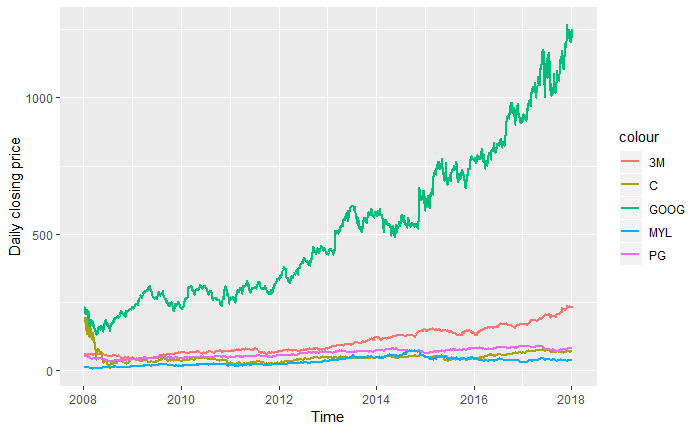

```r
# Load necessary packages
library(tidyverse)
library(ggplot2)
# View time plot of the closing price
 ggplot(data = transformed_data.close,
        aes(x=as.Date(close_price$date), y=value, group=1) ) +
        geom_line(aes(y=close_price$MMM, col='3M'), size = 1) +
        geom_line(aes(y=close_price$C, col='C'), size = 1) +
        geom_line(aes(y=close_price$PG, col='PG'), size = 1) +
        geom_line(aes(y=close_price$GOOG, col='GOOG'), size = 1) +
        geom_line(aes(y=close_price$MYL, col='MYL'), size = 1) +
        labs(x = "Time", y = "Daily closing price")
```

By looking at the daily closing price in 10 years from 2008 to 2018, I could see that the growth of the close price for GOOG (Alphabet Inc.) was positively growth over time. Initially, C (Citigroup Inc.) has a similar close price in 2008. However, their got a negative trend from early 2008 to mid 2008 which made them stuck for years ahead. Interestingly, even though the MMM (3M Company)’s performance was overshadowed with GOOG, they enjoyed quite a positive trend. The 3 others assets have a similar stagnant closing price over time.

Generate a time plot series of return series

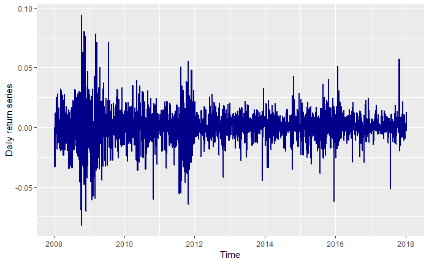

```r
# View time plot of the 3M return price
 ggplot(data = transformed_data.returns,
        aes(x=as.Date(returns$date), y=value, group=1) ) +
        geom_line(aes(y=returns$MMM, col='3M'), size = 1, color='darkblue') +
        labs(x = "Time", y = "Daily return series")
```

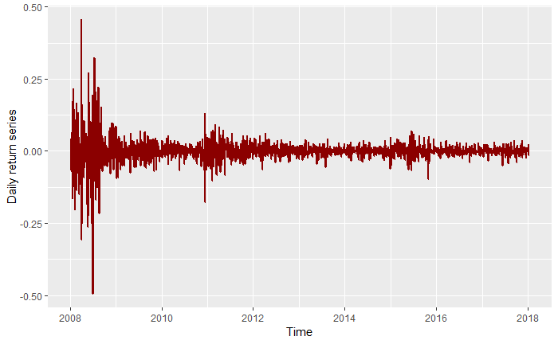

```r
# View time plot of the C return price
 ggplot(data = transformed_data.returns,
        aes(x=as.Date(returns$date), y=value, group=1) ) +
        geom_line(aes(y=returns$C, col='C'), size = 1, color='darkred') +
        labs(x = "Time", y = "Daily return series")
```

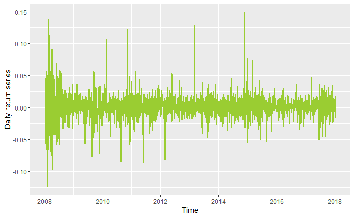

```r
# View time plot of the GOOG return price
 ggplot(data = transformed_data.returns,
        aes(x=as.Date(returns$date), y=value, group=1) ) +
        geom_line(aes(y=returns$GOOG, col='GOOG'), size = 1, color='yellowgreen') +
        labs(x = "Time", y = "Daily return series")
```

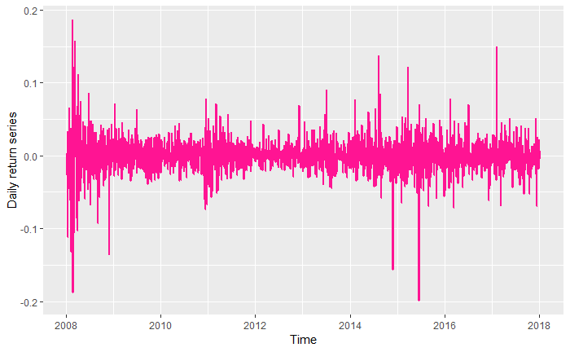

```r
# View time plot of the MYL return price
 ggplot(data = transformed_data.returns,
        aes(x=as.Date(returns$date), y=value, group=1) ) +
        geom_line(aes(y=returns$MYL, col='MYL'), size = 1, color='deeppink') +
        labs(x = "Time", y = "Daily return series")
```

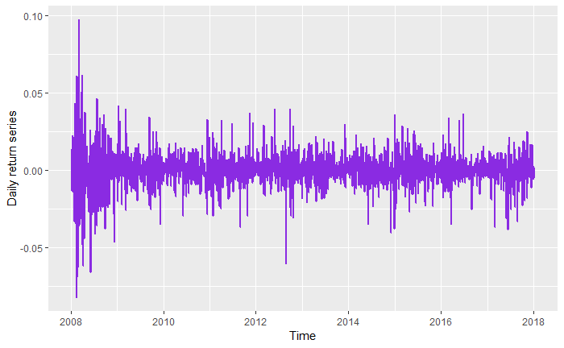

```r
# View time plot of the PG return price
 ggplot(data = transformed_data.returns,
        aes(x=as.Date(returns$date), y=value, group=1) ) +
        geom_line(aes(y=returns$PG, col='PG'), size = 1, color='blueviolet') +
        labs(x = "Time", y = "Daily return series")
```

Discussion: Similarities

The average value of all assets over 10 years was quite stable where the mean of log return is almost zero.

Difference - MMM (Surya)

The average value of 3M asset over 10 years was quite stable where the mean of log return is almost zero. However, the volatility becomes larger for quite a long time at the end of 2008 and at the end of 2011; for a short time at the end of 2015 and mid 2017.

Generate a kernel density plot of return series

```r
library(kdensity)
# MMM
hist(transformed_data.returns$returns.MMM, breaks = 64, freq = FALSE, main = "3M Company", xlab = "Daily log returns")
kde_mmm = kdensity(transformed_data.returns$returns.MMM, start = "normal")
```

```
namespace 㤼㸱extraDistr㤼㸲 is not available and has been replaced
by .GlobalEnv when processing object 㤼㸱options㤼㸲
```

```r
lines(kde_mmm, col="blue")
```

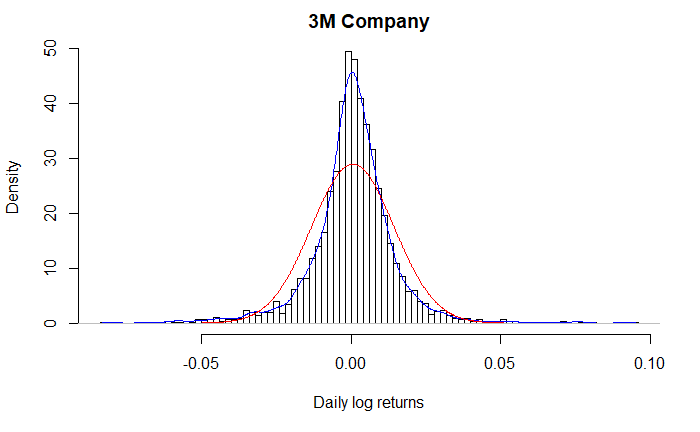

```r
lines(kde_mmm, plot_start = TRUE, col="red")
```

```r
# C
hist(transformed_data.returns$returns.C, breaks = 64, freq = FALSE, main = "Citigroup Inc.", xlab = "Daily log returns")
kde_c = kdensity(transformed_data.returns$returns.C, start = "normal")
lines(kde_c, col="blue")
```

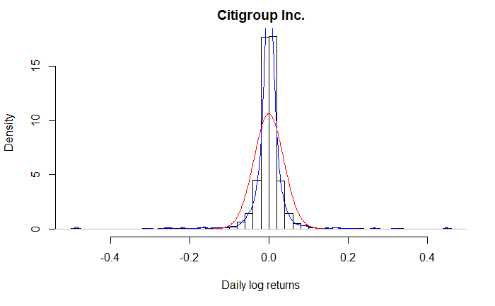

```r
lines(kde_c, plot_start = TRUE, col="red")
```

```r
# PG
hist(transformed_data.returns$returns.PG, breaks = 64, freq = FALSE, main = "The Procter & Gamble Company", xlab = "Daily log returns")
kde_pg = kdensity(transformed_data.returns$returns.PG, start = "normal")
lines(kde_pg, col="blue")
```

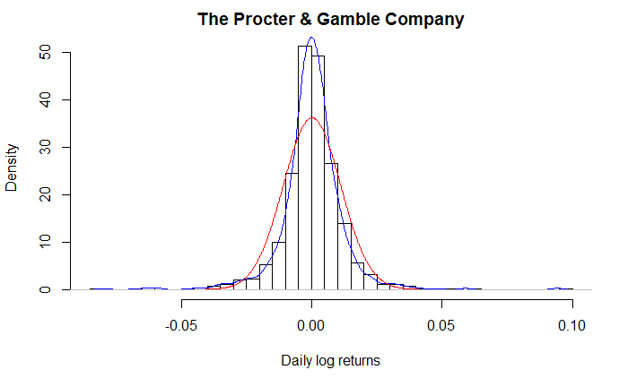

```r
lines(kde_pg, plot_start = TRUE, col="red")
```

```r
# GOOG
hist(transformed_data.returns$returns.GOOG, breaks = 64, freq = FALSE, main = "Alphabet Inc.", xlab = "Daily log returns")
kde_goog = kdensity(transformed_data.returns$returns.GOOG, start = "normal")
lines(kde_goog, col="blue")
```

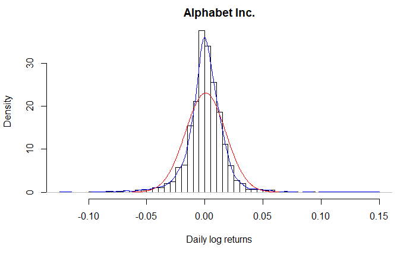

```r
lines(kde_goog, plot_start = TRUE, col="red")
```

```r
# MYL
hist(transformed_data.returns$returns.MYL, breaks = 64, freq = FALSE, main = "Mylan N.V.", xlab = "Daily log returns")
kde_myl = kdensity(transformed_data.returns$returns.MYL, start = "normal")
lines(kde_myl, col="blue")
```

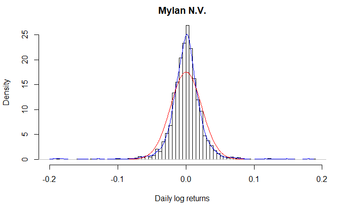

```r
lines(kde_myl, plot_start = TRUE, col="red")
```

Difference - MMM (Surya)

There is a slight different in the left and left side which the density is quite lower than the right side. Thus, we could say that the data doesn’t normally distributed. The kernel density has a higher kurtosis which result in much longer than normal tails of the density.

Generate a normal Q-Q plot of return series

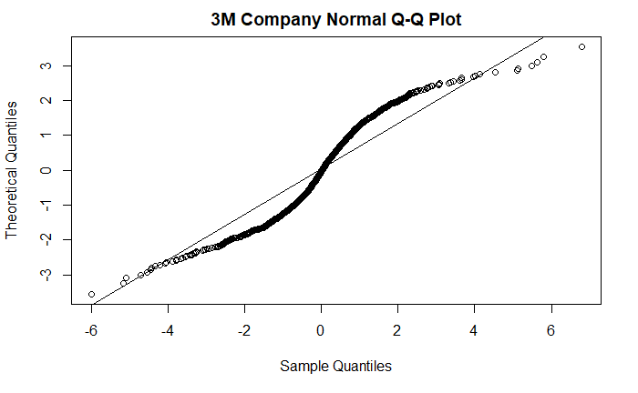

```r
#MMM
mean_mmm = mean(transformed_data.returns$returns.MMM)
sd_mmm = sd(transformed_data.returns$returns.MMM)
mmm_std = (transformed_data.returns$returns.MMM - mean_mmm) / sd_mmm
qqnorm(mmm_std, main="3M Company Normal Q-Q Plot", plot.it = TRUE, datax = TRUE)
qqline(mmm_std, datax = FALSE, distribution = qnorm, probs = c(0.25, 0.75), qtype = 7)
```

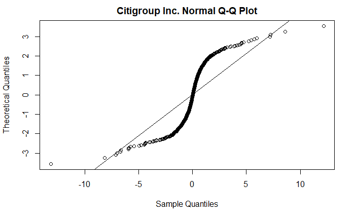

```r
#C
mean_c = mean(transformed_data.returns$returns.C)
sd_c = sd(transformed_data.returns$returns.C)
c_std = (transformed_data.returns$returns.C - mean_c) / sd_c
qqnorm(c_std, main="Citigroup Inc. Normal Q-Q Plot", plot.it = TRUE, datax = TRUE)
qqline(c_std, datax = FALSE, distribution = qnorm, probs = c(0.25, 0.75), qtype = 7)
```

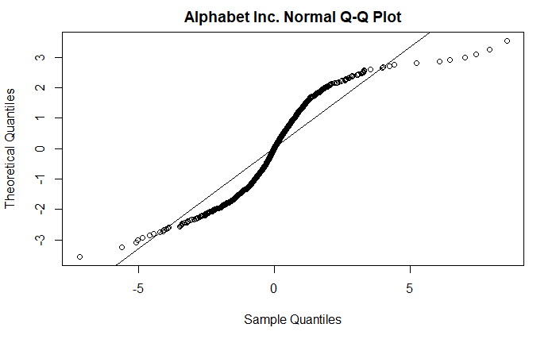

```r
#GOOG
mean_goog = mean(transformed_data.returns$returns.GOOG)
sd_goog = sd(transformed_data.returns$returns.GOOG)
goog_std = (transformed_data.returns$returns.GOOG - mean_goog) / sd_goog
qqnorm(goog_std, main="Alphabet Inc. Normal Q-Q Plot", plot.it = TRUE, datax = TRUE)
qqline(goog_std, datax = FALSE, distribution = qnorm, probs = c(0.25, 0.75), qtype = 7)
```

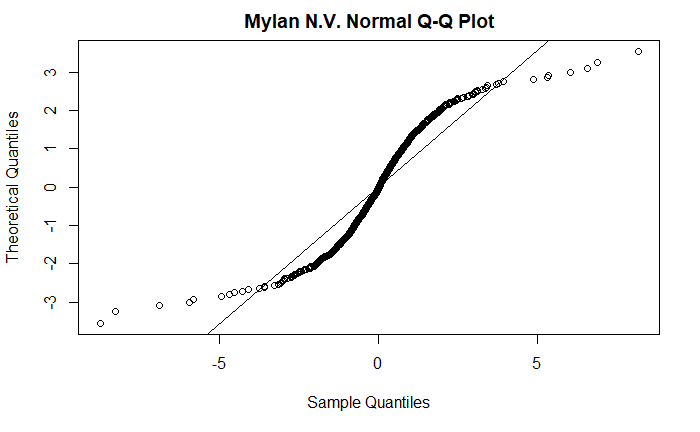

```r
#MYL
mean_myl = mean(transformed_data.returns$returns.MYL)
sd_myl = sd(transformed_data.returns$returns.MYL)
myl_std = (transformed_data.returns$returns.MYL - mean_myl) / sd_myl
qqnorm(myl_std, main="Mylan N.V. Normal Q-Q Plot", plot.it = TRUE, datax = TRUE)
qqline(myl_std, datax = FALSE, distribution = qnorm, probs = c(0.25, 0.75), qtype = 7)
```

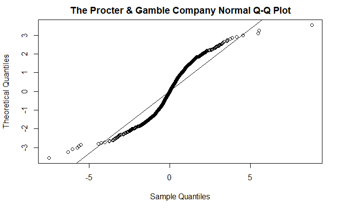

```r
#PG
mean_pg = mean(transformed_data.returns$returns.PG)
sd_pg = sd(transformed_data.returns$returns.PG)
pg_std = (transformed_data.returns$returns.PG - mean_pg) / sd_pg
qqnorm(pg_std, main="The Procter & Gamble Company Normal Q-Q Plot", plot.it = TRUE, datax = TRUE)
qqline(pg_std, datax = FALSE, distribution = qnorm, probs = c(0.25, 0.75), qtype = 7)
```

Difference - MMM (Surya) The 3M asset has a thick tails which mean that, compared to the normal distribution, there is more data located at the extremes of the distribution and less data in the center of the distribution. In terms of quantiles this means that the first quantile is much less than the first theoretical quantile and the last quantile is greater than the last theoretical quantile.

Generate a scatter plot of return series for one asset againts the others

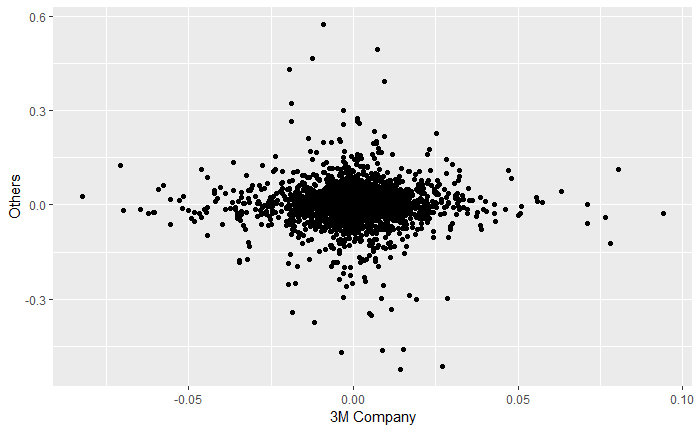

```r
ggplot(data = transformed_data.returns, aes(returns$MMM, (returns$C + returns$PG + returns$GOOG + returns$MYL))) +
  geom_point() +
  labs(x = "3M Company", y = "Others")
```

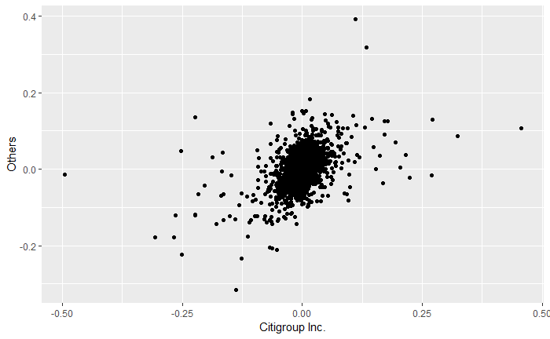

```r
ggplot(data = transformed_data.returns, aes(returns$C, (returns$MMM + returns$PG + returns$GOOG + returns$MYL))) +
  geom_point() +
  labs(x = "Citigroup Inc.", y = "Others")
```

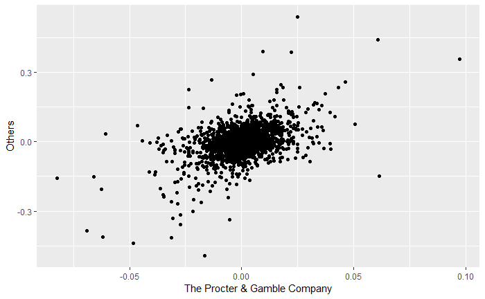

```r
ggplot(data = transformed_data.returns, aes(returns$PG, (returns$MMM + returns$C + returns$GOOG + returns$MYL))) +
  geom_point() +
  labs(x = "The Procter & Gamble Company", y = "Others")
```

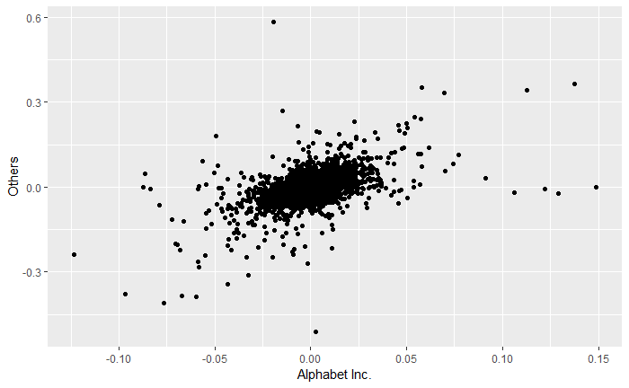

```r
ggplot(data = transformed_data.returns, aes(returns$GOOG, (returns$MMM + returns$C + returns$PG + returns$MYL))) +
  geom_point() +
  labs(x = "Alphabet Inc.", y = "Others")
```

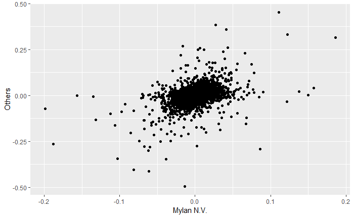

```r
ggplot(data = transformed_data.returns, aes(returns$MYL, (returns$MMM + returns$C + returns$GOOG + returns$PG))) +
  geom_point() +
  labs(x = "Mylan N.V.", y = "Others")
```

Compute the correlation matrix between all assets

```r
return_assets <- data.frame(transformed_data.returns$returns.MMM, transformed_data.returns$returns.C, transformed_data.returns$returns.GOOG, transformed_data.returns$returns.MYL, transformed_data.returns$returns.PG)

cor(return_assets)
```

[output not shown]

SECTION 2 - UNIVARIATE TIME SERIES ANALYSIS

Load required libraries

```r
library(stats)
library(tseries)
library(forecast)
```

SECTION 2.1 - AUTOCORRELATION Stationary analysis of the price series

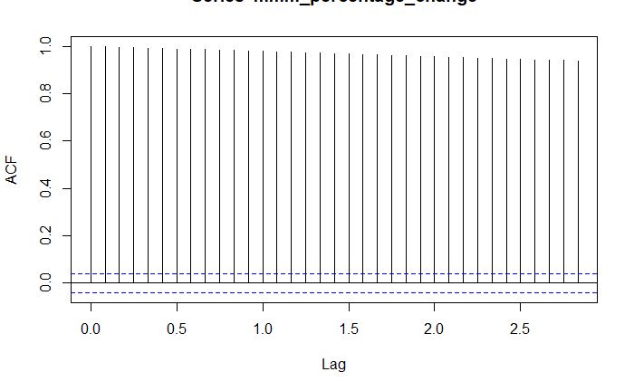

```r
# MMM
mmm_percentage_change <- ts(transformed_data.close$close_price.MMM, frequency = 12, start = 2008)
mmm_percentage_change_truncated <- window(mmm_percentage_change, start = 2013)
acf(mmm_percentage_change)
```

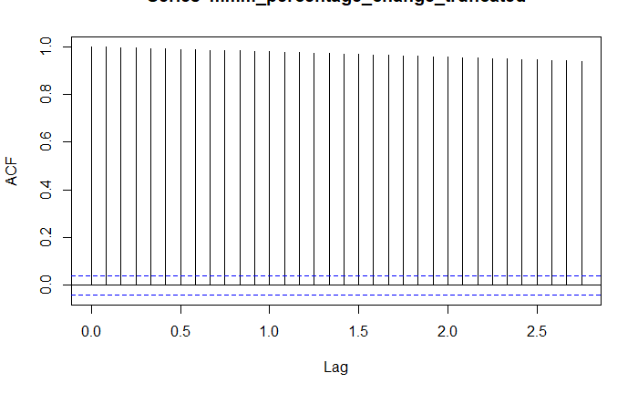

```r
acf(mmm_percentage_change_truncated)
```

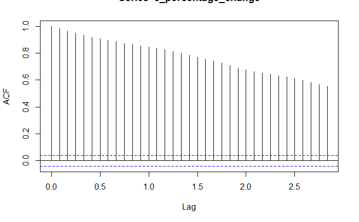

```r
# C
c_percentage_change <- ts(transformed_data.close$close_price.C, frequency = 12, start = 2008)
c_percentage_change_truncated <- window(c_percentage_change, start = 2013)
acf(c_percentage_change)
```

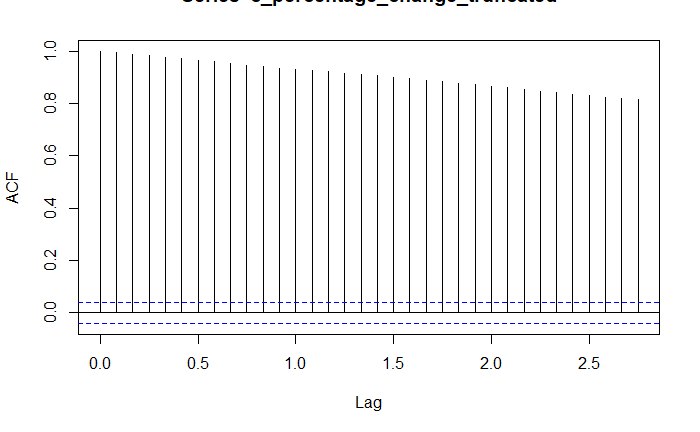

```r
acf(c_percentage_change_truncated)
```

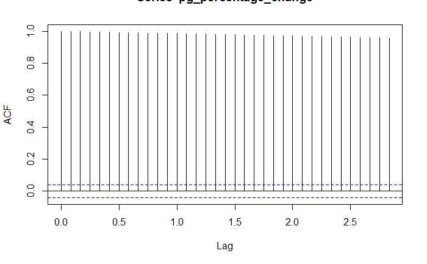

```r
# PG
pg_percentage_change <- ts(transformed_data.close$close_price.PG, frequency = 12, start = 2008)
pg_percentage_change_truncated <- window(pg_percentage_change, start = 2013)
acf(pg_percentage_change)
```

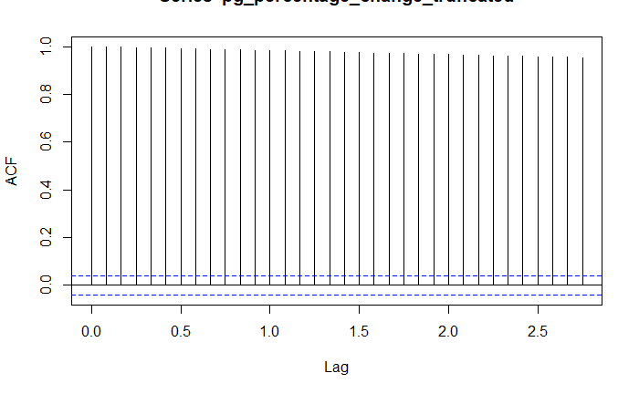

```r
acf(pg_percentage_change_truncated)
```

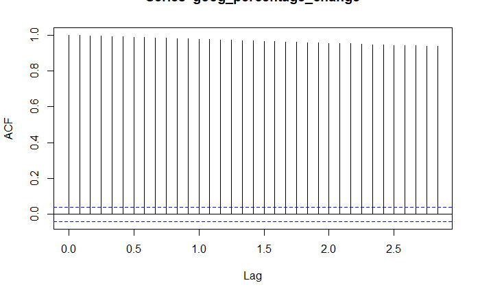

```r
# GOOG
goog_percentage_change <- ts(transformed_data.close$close_price.GOOG, frequency = 12, start = 2008)
goog_percentage_change_truncated <- window(goog_percentage_change, start = 2013)
acf(goog_percentage_change)
```

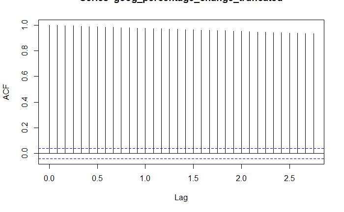

```r
acf(goog_percentage_change_truncated)
```

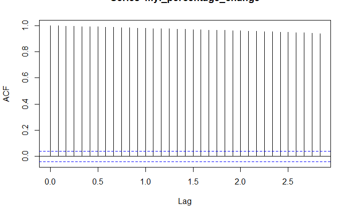

```r
# MYL
myl_percentage_change <- ts(transformed_data.close$close_price.MYL, frequency = 12, start = 2008)
myl_percentage_change_truncated <- window(myl_percentage_change, start = 2013)
acf(myl_percentage_change)
```

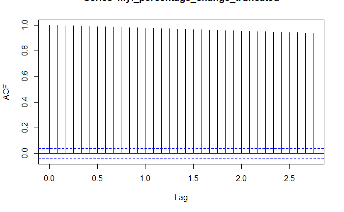

```r
acf(myl_percentage_change_truncated)
```

Difference - MMM (Surya)

In this full autocorrelation, the spike was quite stable on each lag, where it barely decreased. Because the spike has a value that is significantly different from zero, it becomes the evidence of autocorrelation. It also means when the close price of MMM stock rises, it tends to continue rising and vise versa. It also means that this is a non-stationary series because it is decaying.

The truncated autocorrelation also shows quite a similar result with the full autocorrelation which reinforced my argument that the MMM asset is quite stable over time.